# STAT 425 Homework 8

Kefu Zhu, kefuzhu2

# Problem 1

```r
library(faraway)
attach(salmonella)
```

**(a)**

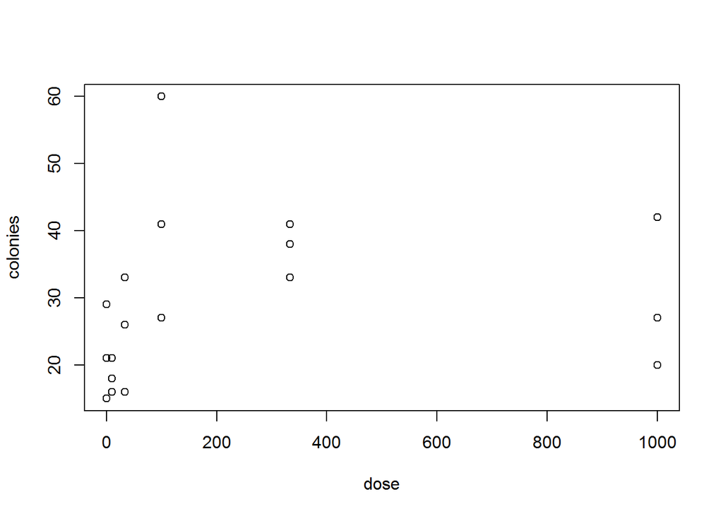

```r
plot(dose,colonies)
```

**My answer**: The mean number of colonies is not directly proportional to dose.

**(b)**

```r
fit1 <- glm(colonies ~ dose,family = poisson)
summary(fit1)
```

```
##
## Call:
## glm(formula = colonies ~ dose, family = poisson)
##
## Deviance Residuals:
##     Min       1Q   Median       3Q      Max
## -2.6482  -1.8225  -0.2993   1.2917   5.1861
##
## Coefficients:
##              Estimate Std. Error z value Pr(>|z|)
## (Intercept) 3.3219950  0.0540292  61.485   <2e-16 ***
## dose        0.0001901  0.0001172   1.622    0.105
## ---
## Signif. codes:  0 '***' 0.001 '**' 0.01 '*' 0.05 '.' 0.1 ' ' 1
##
## (Dispersion parameter for poisson family taken to be 1)
##
##     Null deviance: 78.358  on 17  degrees of freedom
## Residual deviance: 75.806  on 16  degrees of freedom
## AIC: 172.34
##
## Number of Fisher Scoring iterations: 4
```

**(c)**

```r
pchisq(deviance(fit1), df.residual(fit1), lower = FALSE)
```

```
## [1] 9.396451e-10
```

**My answer**: Since the p-value is 9.396451e-10, I conclude that there is evidence of lack of fit.

**(d)**

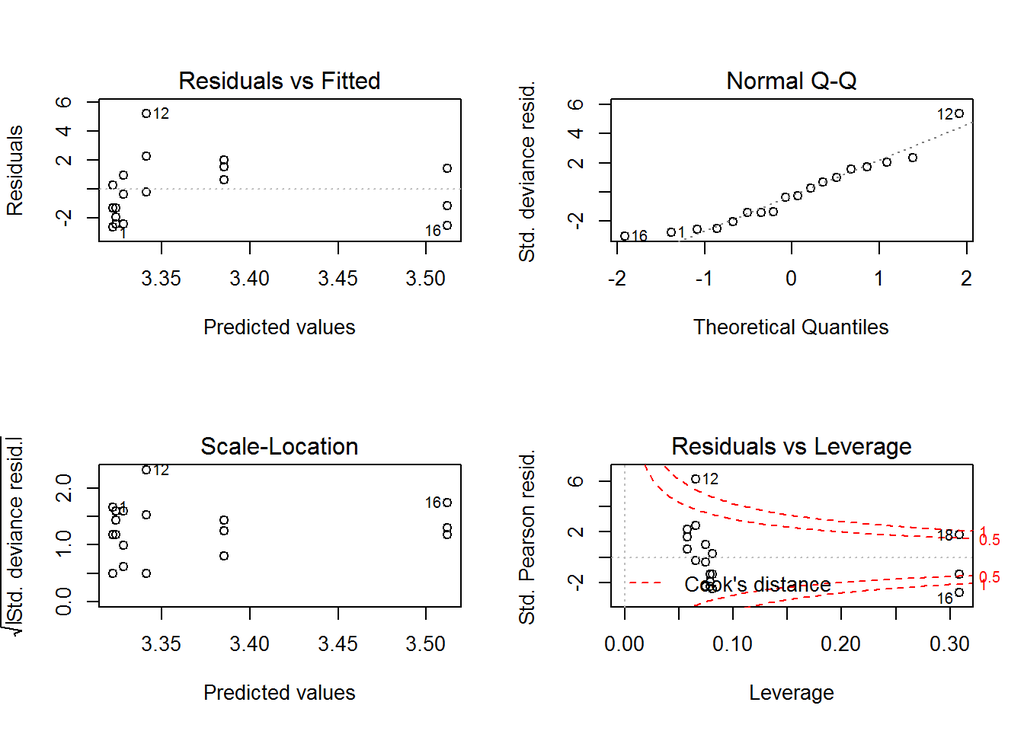

```r
par(mfrow = c(2,2))
plot(fit1,add.smooth = FALSE)
```

**My answer**: There are no outliers based on the Normal Q-Q plot. From the residuals vs. leverage plot, observation 12, 18 and 16 seem to be influential.

**(e)**

```r
fit1_cubic <- glm(colonies ~ dose + I(dose ^ 2) + I(dose ^ 3),family = poisson)
summary(fit1_cubic)
```

```
##
## Call:
## glm(formula = colonies ~ dose + I(dose^2) + I(dose^3), family = poisson)
##
## Deviance Residuals:
##      Min        1Q    Median        3Q       Max
## -2.43608  -0.85295  -0.07833   0.56028   2.65580
##
## Coefficients:
##               Estimate Std. Error z value Pr(>|z|)
## (Intercept)  2.930e+00  8.988e-02  32.595  < 2e-16 ***
## dose         1.141e-02  2.051e-03   5.563 2.65e-08 ***
## I(dose^2)   -3.653e-05  7.602e-06  -4.805 1.54e-06 ***
## I(dose^3)    2.558e-08  5.668e-09   4.514 6.37e-06 ***
## ---
## Signif. codes:  0 '***' 0.001 '**' 0.01 '*' 0.05 '.' 0.1 ' ' 1
##
## (Dispersion parameter for poisson family taken to be 1)
##
##     Null deviance: 78.358  on 17  degrees of freedom
## Residual deviance: 36.055  on 14  degrees of freedom
## AIC: 136.59
##
## Number of Fisher Scoring iterations: 4
```

**(f)**

```r
pchisq(deviance(fit1_cubic), df.residual(fit1_cubic), lower = FALSE)
```

```
## [1] 0.001023672
```

**My answer**: Since the p-value is 0.0010237, I conclude that there is evidence of lack of fit.

**(g)**

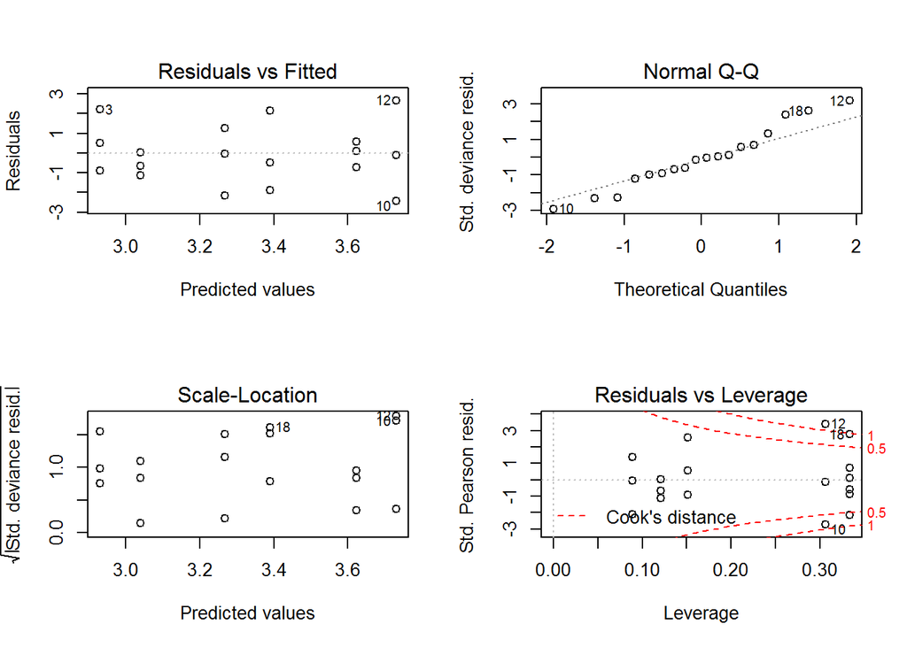

```r
par(mfrow = c(2,2))
plot(fit1_cubic,add.smooth = FALSE)
```

**My answer**: There are no outliers based on the Normal Q-Q plot. From the residuals vs. leverage plot, observation 12, 18 and 10 seem to be influential.

**(h)**

```r
# Chi-sqaure statistic
chi_square <- sum(residuals(fit1_cubic,type = "pearson") ^ 2)
chi_square
```

```
## [1] 36.56925
```

```r
# Dispersino parameter
dispersion_parameter <- chi_square / df.residual(fit1_cubic)
dispersion_parameter
```

```
## [1] 2.61209
```

**(i)**

```r
summary(fit1_cubic,dispersion = dispersion_parameter)
```

```
##
## Call:
## glm(formula = colonies ~ dose + I(dose^2) + I(dose^3), family = poisson)
##
## Deviance Residuals:
##      Min        1Q    Median        3Q       Max
## -2.43608  -0.85295  -0.07833   0.56028   2.65580
##
## Coefficients:
##               Estimate Std. Error z value Pr(>|z|)
## (Intercept)  2.930e+00  1.453e-01  20.168  < 2e-16 ***
## dose         1.141e-02  3.314e-03   3.442 0.000577 ***
## I(dose^2)   -3.653e-05  1.229e-05  -2.973 0.002946 **
## I(dose^3)    2.558e-08  9.160e-09   2.793 0.005226 **
## ---
## Signif. codes:  0 '***' 0.001 '**' 0.01 '*' 0.05 '.' 0.1 ' ' 1
##
## (Dispersion parameter for poisson family taken to be 2.61209)
##
##     Null deviance: 78.358  on 17  degrees of freedom
## Residual deviance: 36.055  on 14  degrees of freedom
## AIC: 136.59
##
## Number of Fisher Scoring iterations: 4
```

**My answer**: Since the p-value is 0.005226, so the cubic term is statistically significant and should be included.

# Problem 2

```r
attach(dvisits)
```

**(a)**

```r
fit2 <-
  glm(
    doctorco ~ sex + age + agesq + income + levyplus + freepoor + freerepa +
      illness + actdays + hscore + chcond1 + chcond2,family = poisson
  )
summary(fit2)
```

```
##
## Call:
## glm(formula = doctorco ~ sex + age + agesq + income + levyplus +
##     freepoor + freerepa + illness + actdays + hscore + chcond1 +
##     chcond2, family = poisson)
##
## Deviance Residuals:
##     Min       1Q   Median       3Q      Max
## -2.9170  -0.6862  -0.5743  -0.4839   5.7005
##
## Coefficients:
##              Estimate Std. Error z value Pr(>|z|)
## (Intercept) -2.223848   0.189816 -11.716   <2e-16 ***
## sex          0.156882   0.056137   2.795   0.0052 **
## age          1.056299   1.000780   1.055   0.2912
## agesq       -0.848704   1.077784  -0.787   0.4310
## income      -0.205321   0.088379  -2.323   0.0202 *
## levyplus     0.123185   0.071640   1.720   0.0855 .
## freepoor    -0.440061   0.179811  -2.447   0.0144 *
## freerepa     0.079798   0.092060   0.867   0.3860
## illness      0.186948   0.018281  10.227   <2e-16 ***
## actdays      0.126846   0.005034  25.198   <2e-16 ***
## hscore       0.030081   0.010099   2.979   0.0029 **
## chcond1      0.114085   0.066640   1.712   0.0869 .
## chcond2      0.141158   0.083145   1.698   0.0896 .
## ---
## Signif. codes:  0 '***' 0.001 '**' 0.01 '*' 0.05 '.' 0.1 ' ' 1
##
## (Dispersion parameter for poisson family taken to be 1)
##
##     Null deviance: 5634.8  on 5189  degrees of freedom
## Residual deviance: 4379.5  on 5177  degrees of freedom
## AIC: 6737.1
##
## Number of Fisher Scoring iterations: 6
```

**(b)** **My answer**: No. The value of the response variable is too small.

**(c)**

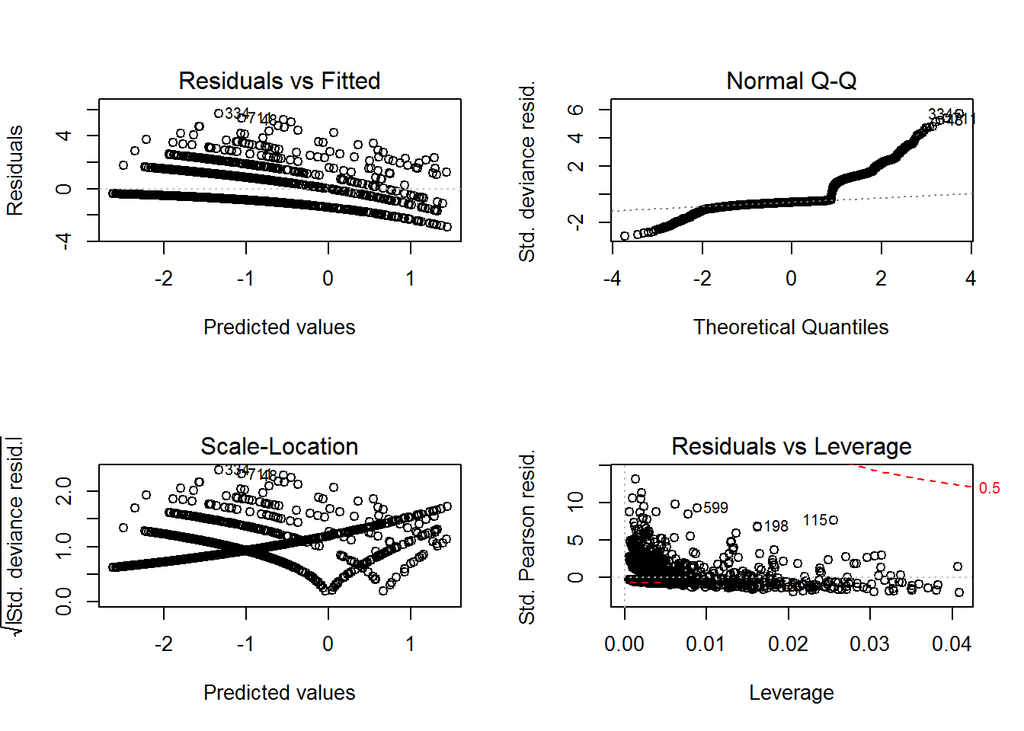

```r
par(mfrow=c(2,2))
plot(fit2,add.smooth = FALSE)
```

**My answer**: The default plots do not show any outliers or influential points.

**(d)**

**My answer**: Since the p-value of freepoor is 0.0144 and its estimated coefficient is not zero, so the expected number of doctor/specialist consultations (in the last two weeks) is different for individuals who, because of low income, recent immigration, or unemployment, are covered by the government.

**(e)**

```r
exp(coef(fit2)["sex"])
```

```
##      sex
## 1.169858
```

**My answer**: The estimate is a factor of about 1.1698575.

**(f)**

```r
drop1(fit2,test='LRT')
fit2<-update(fit2,~.-agesq)
drop1(fit2,test='LRT')
fit2<-update(fit2,~.-freerepa)
drop1(fit2,test='LRT')
fit2<-update(fit2,~.-levyplus)
drop1(fit2,test='LRT')
fit2<-update(fit2,~.-chcond1)
drop1(fit2,test='LRT')
fit2<-update(fit2,~.-chcond2)
drop1(fit2,test='LRT')
```

```r
summary(fit2)
```

```
##
## Call:
## glm(formula = doctorco ~ sex + age + income + freepoor + illness +
##     actdays + hscore, family = poisson)
##
## Deviance Residuals:
##     Min       1Q   Median       3Q      Max
## -2.9258  -0.6829  -0.5752  -0.4945   5.6960
##
## Coefficients:
##              Estimate Std. Error z value Pr(>|z|)
## (Intercept) -2.051963   0.099522 -20.618  < 2e-16 ***
## sex          0.175529   0.055433   3.167  0.00154 **
## age          0.433532   0.137140   3.161  0.00157 **
## income      -0.171053   0.081926  -2.088  0.03681 *
## freepoor    -0.496325   0.175304  -2.831  0.00464 **
## illness      0.196008   0.017585  11.146  < 2e-16 ***
## actdays      0.127793   0.004899  26.088  < 2e-16 ***
## hscore       0.032433   0.009938   3.263  0.00110 **
## ---
## Signif. codes:  0 '***' 0.001 '**' 0.01 '*' 0.05 '.' 0.1 ' ' 1
##
## (Dispersion parameter for poisson family taken to be 1)
##
##     Null deviance: 5634.8  on 5189  degrees of freedom
## Residual deviance: 4388.1  on 5182  degrees of freedom
## AIC: 6735.7
##
## Number of Fisher Scoring iterations: 6
```

# Problem 3

```r
library(lme4)
attach(Dyestuff)
```

**(a)**

```r
fit3_fix <- lm(Yield ~ Batch)
anova(fit3_fix)
```

```
## Analysis of Variance Table
##
## Response: Yield
##           Df Sum Sq Mean Sq F value   Pr(>F)
## Batch      5  56358 11271.5  4.5983 0.004398 **
## Residuals 24  58830  2451.2
## ---
## Signif. codes:  0 '***' 0.001 '**' 0.01 '*' 0.05 '.' 0.1 ' ' 1
```

**My answer**: The p-value of Batch effect is 0.004398.

**(b)**

```r
fit3_reml <- lmer(Yield ~ (1|Batch))
summary(fit3_reml)
```

```
## Linear mixed model fit by REML ['lmerMod']
## Formula: Yield ~ (1 | Batch)
##
## REML criterion at convergence: 319.7
##
## Scaled residuals:
##     Min      1Q  Median      3Q     Max
## -1.4117 -0.7634  0.1418  0.7792  1.8296
##
## Random effects:
##  Groups   Name        Variance Std.Dev.
##  Batch    (Intercept) 1764     42.00
##  Residual             2451     49.51
## Number of obs: 30, groups:  Batch, 6
##
## Fixed effects:
##             Estimate Std. Error t value
## (Intercept)  1527.50      19.38    78.8
```

**(c)**

```r
rho <- (1764)/(1764+2451)
rho
```

```
## [1] 0.4185053
```

**My answer**: The estimate of the intra-class correlation coefficient is 0.4185053.

**(d)**

```r
fit3_ml <- lmer(Yield ~ (1|Batch), REML = FALSE)
summary(fit3_ml)
```

```
## Linear mixed model fit by maximum likelihood  ['lmerMod']
## Formula: Yield ~ (1 | Batch)
##
##      AIC      BIC   logLik deviance df.resid
##    333.3    337.5   -163.7    327.3       27
##
## Scaled residuals:
##     Min      1Q  Median      3Q     Max
## -1.4315 -0.7972  0.1480  0.7721  1.8037
##
## Random effects:
##  Groups   Name        Variance Std.Dev.
##  Batch    (Intercept) 1388     37.26
##  Residual             2451     49.51
## Number of obs: 30, groups:  Batch, 6
##
## Fixed effects:
##             Estimate Std. Error t value
## (Intercept)  1527.50      17.69   86.33
```

**(e)**

```r
nullmod <- lm(Yield ~ 1)
llrts <- as.numeric(2 * (logLik(fit3_ml) - logLik(nullmod)))
llrts
```

```
## [1] 5.402826
```

```r
pchisq(llrts,1,lower=FALSE)
```

```
## [1] 0.02010417
```

**My answer**: The log-likelihood ratio test statistic is 5.4028261 with p-value of 0.0201042.